# Introdução a modelos lineares mistos para os estudos da linguagem (aula 3)

Mahayana C. Godoy (PPgEL/UFRN)

16/11/2019

> **Para citar este material:**

> Godoy, M. C. (2019). Introdução aos modelos lineares mistos para os estudos da linguagem. PsyArXiv. https://doi.org/10.17605/OSF.IO/9T8UR

## 3. Modelos Lineares Mistos: conceitos básicos

> Parte do texto desse tutorial é conteúdo de Godoy e Nunes (em preparação)

Nesta seção, vamos aprender a lidar com dados de medidas repetidas, que violam a hipótese de independência. Os tópicos de que trataremos serão:

1. Conceitos básicos de um Modelo Linear Misto (MLM)
2. Ajuste de um MLM usando o pacote lme4 para `R`
3. Modelos com mais de um efeito fixo
4. Comparação por modelos aninhados

Enquanto você acompanha a parte introdutória do tutorial, baixe os novos pacotes que serão usados para as atividades e carregue os pacotes que serão necessários:

```r
# baixar pacotes (esses pacotes serão carregados mais adiante)

install.packages("lme4")
install.packages("lmerTest")

#carregar pacotes

library(lme4)
library(ggplot2)
library(dplyr)

# o pacote lmerTest será carregado posteriormente
```

## 3.1 Medidas repetidas e efeitos aleatórios

Até agora, assumimos que a independência é pré-requisito para aplicação dos modelos lineares vistos. No entanto, dados oriundos de corpora e experimentação dificilmente preenchem esse critério. Para ilustrar o caso, tomemos um experimento simples de *priming* semântico tal qual descrito em Godoy e Nunes (*em preparação*):

Aqui não usamos o mesmo conjunto de dados que Godoy e Nunes, mas simulamos os dados de um experimento idêntico e os salvamos na planilha `priming.csv`, que inspecionamos com os comandos abaixo.

```r
#importar conjunto de dados

priming <- read.csv("dados/priming.csv")

#inspecionar dados

head(priming)
```

```
#>      item participante       prime   SOA    tempo  resposta
#> 1 item_01         S_01 relacionado curto 688.0820   correct
#> 2 item_02         S_01 relacionado curto 694.6091   correct
#> 3 item_03         S_01 relacionado curto 499.6528 incorrect
#> 4 item_04         S_01 relacionado curto 585.7681   correct
#> 5 item_05         S_01 relacionado curto 480.8825   correct
#> 6 item_06         S_01 relacionado curto 492.4530 incorrect
```

```r
#conhecer variáveis

str(priming)
```

```
#> 'data.frame':    1200 obs. of  6 variables:
#>  $ item        : Factor w/ 60 levels "item_01","item_02",..: 1 2 3 4 5 6 7 8 9 10 ...
#>  $ participante: Factor w/ 20 levels "S_01","S_02",..: 1 1 1 1 1 1 1 1 1 1 ...
#>  $ prime       : Factor w/ 2 levels "nrelacionado",..: 2 2 2 2 2 2 2 2 2 2 ...
#>  $ SOA         : Factor w/ 2 levels "curto","longo": 1 1 1 1 1 1 1 1 1 1 ...
#>  $ tempo       : num  688 695 500 586 481 ...
#>  $ resposta    : Factor w/ 2 levels "correct","incorrect": 1 1 2 1 1 2 1 1 1 1 ...
```

O conjunto de dados contém 6 colunas:

> `participante`, com identificação dos participantes da pesquisa;

> `SOA`, uma condição experimental que entenderemos depois;

> `tempo`: tempo de resposta dos participantes em milissegundos.

Para fazer a análise dos dados, precisamos primeiro inspecioná-los e identificar possíveis *outliers*.

### 3.1.1 Inspeção e limpeza dos dados

Como vimos anteriormente, modelos lineares mistos costumam assumir que seus resíduos seguem uma distribuição normal, e essa hipótese é mais fácil de não ser violada se a distribuição dos dados já segue essa distribuição. Portanto, convém inspecionar nossos dados para avaliar se sua distribuição é normal. Façamos isso com um gráfico Q-Q (mas você pode usar um histograma ou um boxplot se preferir).

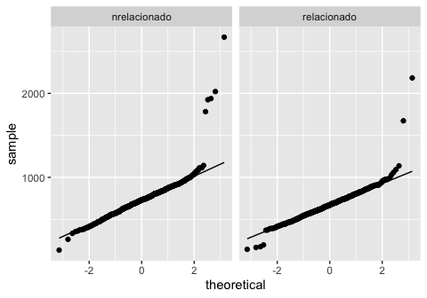

```r
## Conferindo distribuição de dados

ggplot(priming, aes(sample = tempo))+
  stat_qq()+
  stat_qq_line()+
  facet_wrap(~prime)
```

Vemos que a distribuição de dados é normal, mas também identificamos alguns valores muito mais altos que os outros. Convém definir se esses valores permanecerão em nossa análise.

A decisão de tirar ou não observações do conjunto de dados depende de uma séries de fatores, como o fenômeno a ser modelado, a natureza experimental ou observacional dos dados, a intenção da análise estatística e (no caso de experimentos) e o tipo de tarefa feita pelo participante da pesquisa. Para experimentos de *priming*, costumamos descartar valores menores de 200ms, pois considera-se que antes desse tempo não é possível haver acesso lexical. Também podemos descartar os valores acima de 1500ms por estarem muito distantes dos valores médios, e também seguindo o que fazem alguns pesquisadores na literatura (cf. Baayen (2008) em seu capítulo sobre modelos lineares mistos).

Por fim, nós também vamos excluir todas as decisões que foram respondidas erroneamente pelos participantes, ou seja, todas as observações cuja resposta foi anotada com `incorrect`.

> **Lembre-se:** os critérios de exclusão de dados foram definidos aqui pela natureza da pesquisa desenvolvida. A identificação de outliers e remoção de observações vai variar a depender de sua pergunta de pesquisa e dos dados analisados. Consulte a literatura para justificar suas decisões.

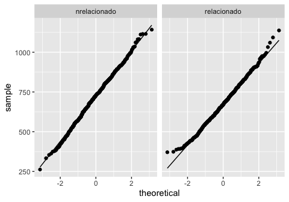

```r
## Selecionando apenas resposta cujo tempo esteja entre 200 ms e 1500 ms e que estejam marcadas como correct para a variável resposta

priming = priming%>%
  filter(tempo > 200 & tempo < 1500 & resposta == "correct")

## Conferindo novamente a distribuição dos dados

ggplot(priming, aes(sample = tempo))+
  stat_qq()+
  stat_qq_line()+
  facet_wrap(~prime)
```

```r
## Vendo a média (em ms) dos tempos de reação para os dois níveis da variável prime

priming%>%
  group_by(prime)%>%
  summarise(mean(tempo))
```

```
#> # A tibble: 2 x 2
#>   prime        `mean(tempo)`
#>   <fct>                <dbl>
#> 1 nrelacionado          722.
#> 2 relacionado           675.
```

Agora que temos nosso conjunto de dados, podemos fazer nossa pergunta: será que o tipo de *prime* afeta o tempo de resposta dos participantes? Vemos acima que, em média, o tempo de resposta foi menor quando o *prime* era relacionado. No entanto, será que isso é um dado confiável, ou essa diferença se deve ao acaso? Para tentar responder essa pergunta, precisamos construir um modelo linear misto que leve em conta os parâmetros do nosso conjunto de dados.

### 3.1.2 Modelo linear misto: interceptos e slopes aleatórios

Como a hipótese do pesquisador é de que um prime relacionado diminuiria o tempo de resposta da palavra alvo, pode-se dizer que o tempo que o participante levava para tomar a decisão é a a **variável resposta**, e o tipo de prime (relacionado ou não) é o **efeito fixo**. Um modelo que quisesse testar a relação entre esse dois termos poderia ser escrito da seguinte maneira:

> tempo ~ relação + $\epsilon$

No entanto, os dados coletados pelo nosso experimentador fictício não são independentes. Como dissemos, cada participante contribuiu com 20 observações para cada condição. Como cada participante é diferente, alguns serão mais rápidos, outros mais lentos. Além disso, alguns podem estar fazendo a tarefa pela primeira vez, enquanto outros já terão participado de outros experimentos e estarão mais à vontade. Por fim, em se tratando de um experimento de *priming*, também é importante considerar que todos terão características próprias no modo como construíram seu vocabulário e como usam a língua no dia a dia. Podemos ver as diferenças entre os participantes olhando o painel gerado pelo código abaixo.

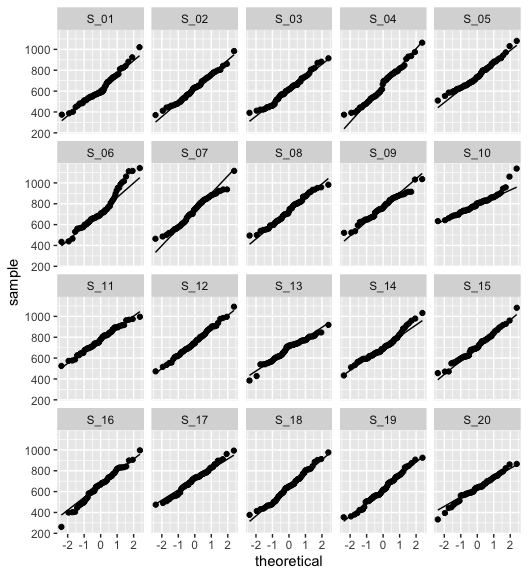

```r
## Conferindo distribuição de dados por participante

ggplot(priming, aes(sample = tempo))+
  stat_qq()+
  stat_qq_line()+
  facet_wrap(~participante)
```

Aqui, vemos que o participante `S_06` tem muitas observações acima de 1000ms, enquanto o `S_20` não tem nenhuma. O `S_10` não tem nenhuma observação abaixo de 500ms, o que indica um tempo de reação um pouco maior que os outros participantes. De fato, se pedirmos para ver a média de resposta de cada participante, veremos resultados muito diferentes.

```r
# Cálculo da média por participante

priming%>%
  group_by(participante)%>%
  summarise(media = mean(tempo))%>%
  arrange(desc(media))
```

```
#> # A tibble: 20 x 2
#>    participante media
#>    <fct>        <dbl>
#>  1 S_10          798.
#>  2 S_11          778.
#>  3 S_09          767.
#>  4 S_12          756.
#>  5 S_05          749.
#>  6 S_06          737.
#>  7 S_07          736.
#>  8 S_08          734.
#>  9 S_17          716.
#> 10 S_15          716.
#> 11 S_14          709.
#> 12 S_13          686.
#> 13 S_16          660.
#> 14 S_04          659.
#> 15 S_18          646.
#> 16 S_20          632.
#> 17 S_02          628.
#> 18 S_01          626.
#> 19 S_19          623.
#> 20 S_03          617.
```

No entanto, não é apenas com relação à média geral do tempo de resposta que os participantes diferem. Considere o painel da **Figura 3.1**. Já vimos um gráfico parecido antes, quando discutimos o conceito de *slope*. Nessa figura, você pode ver que os participantes diferem entre entre si também em relação ao *slope* entre as condições. Os participantes `S_09` e `S_10` tem um *slope* próximo a zero. Para a maioria deles, a diferença entre o nível de referência (`nrel`) e o segundo nível da variável é dado por um slope negativo; para alguns participantes (`S_18`, `S_19` e `S_20`), esse *slope* é positivo.

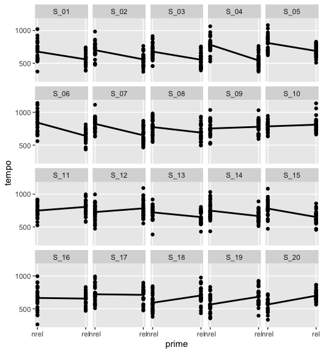

**Figura 3.1**: distribuição de dados por prime para cada participante

É razoável assumir que as características de cada participante devem influenciar suas respostas de maneiras distintas, de modo a afetar a distribuição dos dados. Isso significa que cada participante contribui com uma variabilidade aleatória, não controlada pelo experimentador, mas que deve ser prevista no modelo. Portanto, ao construirmos um modelo estatístico que tente explicar como a condição prime afeta o tempo de reação, seria adequado que esse modelo levasse em conta a variabilidade de cada participante.

Para usarmos a notação da sintaxe do `R`, podemos modelar essa fonte de efeito aleatório do participante da seguinte maneira:

> tempo ~ prime + (1|participante)

Aqui estamos determinando que o modelo considere interceptos diferentes para cada participante (o número 1, aqui, representa o intercepto). Esse intercepto é chamado de **intercepto aleatório**, visto que ele tem por objetivo modelar um fator de variabilidade aleatória: os participantes (nós podemos chamar esse intercepto específico de **intercepto aleatório por participante**).

Para levar em conta essa variabilidade, ampliamos nosso modelo para que ele leve em conta mais um parâmetro: **interceptos aleatórios por item**.

> tempo ~ prime + (1|participante) + (1|item)

Portanto, além de interceptos aleatórios para itens e participantes, precisamos que nosso modelo considere também as diferenças dos declives associados a esses efeitos aleatórios em função do tipo de prime. Esse parâmetro, chamado de *slope* aleatório, pode ser representado em nosso modelo da seguinte maneira:

> tempo ~ prime + (1+prime|participante) + (1+prime|item)

O que a sintaxe `1 + prime|participante` indica é “intercepto aleatório + slope aleatório por prime por participante”. Pensemos assim: para cada participante, queremos saber o quanto suas respostas variam quando ele sai do nível não-relacionado para o nível relacionado da variável *prime*. Por esse motivo, pedimos que o modelo considere o *slope* na condição *prime* para cada participante. O mesmo é feito para os itens experimentais.

A partir da fórmula descrita acima, criamos um **Modelo Linear Misto**, que recebe esse nome porque, dentre seus parâmetros, há tanto efeitos fixos quanto efeitos aleatório. Nesse modelo, o efeito fixo é a condição prime, mas se considera, ao mesmo tempo, variabilidade por item e por participante.

### 3.1.3 Modelos lineares mistos no pacote lme4

Construiremos um modelo linear, chamado `modelo.prime`. Para isso, usaremos a função `lmer` do pacote `lme4`. São dois os argumentos principais desta função. O primeiro deles é a fórmula do Modelo Linear Misto a ser ajustado, já construída anteriormente. Esta fórmula é dada por `tempo ~ prime + (1+prime|participante) + (1+prime|item)`.

Essa sintaxe indica que nossa variável dependente é tempo, nossa variável explicativa (ou seja, o efeito fixo) é prime, e inclui interceptos aleatórios por participante e item, além de slopes aleatórios para prime por participante e item. O segundo argumento é o objeto do `R` no qual os dados estão armazenados. Neste exemplo, nosso conjunto de dados se chama `priming`. Juntando estas duas informações, temos o seguinte:

```r
# carregando o pacote lme4

library(lme4)

# ajustando modelo linear com interceptos aleatórios por item e participante e slopes aleatórios por prime

modelo.prime <- lmer(tempo ~ prime + (1+prime|participante) + (1+prime|item), data = priming)
```

Ao tentarmos rodar o modelo, note que recebemos um aviso preocupante, identificado por `## boundary (singular) fit: see ?isSingular`. Isto indica que o modelo foi sobreajustado, ou seja, ele funciona muito bem para esta amostra em particular, mas não permite generalizações para a população de onde os dados foram obtidos.

Para evitar os problemas de sobreajuste, Barr et al. (2013) sugerem que comecemos a análise da maneira que iniciamos, com a estrutura mais complexa possível para os efeitos aleatórios. Caso o modelo tenha problemas de sobreajuste ou de convergência no método iterativo, devemos simplificar esta estrutura até atingir uma convergência sem problemas. Portanto, iremos simplificar a estrutura dos efeitos aleatórios dos participantes, retirando o *slope* aleatório, mantendo apenas o intercetpo. Manteremos a estrutura dos itens da maneira inicial.

```r
# ajustanto o modelo linear: retira slope aleatório de prime por participante (continua problema de convergência)

modelo.prime <- lmer(tempo ~ prime + (1|participante) + (1+prime|item), data = priming)

# ajustanto o modelo linear: sem slopes aleatórios

modelo.prime <- lmer(tempo ~ prime + (1|participante) + (1|item), data = priming)

# resultado de modelo.prime

summary(modelo.prime)
```

```
#> Linear mixed model fit by REML ['lmerMod']
#> Formula: tempo ~ prime + (1 | participante) + (1 | item)
#>    Data: priming
#>
#> REML criterion at convergence: 14576.2
#>
#> Scaled residuals:
#>      Min       1Q   Median       3Q      Max
#> -3.15182 -0.67768 -0.00772  0.65794  3.03342
#>
#> Random effects:
#>  Groups       Name        Variance Std.Dev.
#>  item         (Intercept)   635.7   25.21
#>  participante (Intercept)  3162.3   56.23
#>  Residual                 15275.4  123.59
#> Number of obs: 1163, groups:  item, 60; participante, 20
#>
#> Fixed effects:
#>                  Estimate Std. Error t value
#> (Intercept)       723.068     13.963  51.786
#> primerelacionado  -48.856      7.255  -6.734
#>
#> Correlation of Fixed Effects:
#>             (Intr)
#> primerelcnd -0.259
```

Desta vez, com a estrutura do efeito aleatório para os participantes simplificada, conseguimos que o modelo ajustado convergisse sem problemas. Através do comando `summary`, vemos os resultados desse modelo. Há, em primeiro lugar, informações sobre os efeitos aleatórios (*random effects*). Nele, vemos a variabilidade dos dados que pode ser explicada pelos efeitos aleatórios do modelo: participantes e itens. Há, ainda, informação de variabilidade residual (*residuals*), que indica a variação que não pode ser explicada pelos parâmetros explícitos no modelo.

A média para as palavras de prime relacionado foi 675.7ms. Isso é 48.8ms a menos que a média do intercepto, como evidencia o valor negativo do coeficiente para a linha `primerelacionado`. Essa linha, portanto, nos dá o valor do coeficiente estimado para a condição relacionada *em comparação* aos valores do intercepto, bem como as estatísticas associadas a esse coeficiente.

Você deve ter notado que o resultado do modelo linear misto não é muito diferente daquele que analisamos quando vimos um modelo linear. Há, contudo, uma diferença: não há p-valor associado aos coeficientes! Se você quiser os p-valores associados aos coeficientes dos efeitos fixos, deverá carregar o pacote `lmerTest` e rodar o modelo mais uma vez.

```r
# carregando o pacote lmerTest

library(lmerTest)

# ajustanto o modelo linear

modelo.prime <- lmer(tempo ~ prime + (1|participante) + (1|item), data = priming)

# resultado de modelo.prime

summary(modelo.prime)
```

```
#> Linear mixed model fit by REML. t-tests use Satterthwaite's method [
#> lmerModLmerTest]
#> Formula: tempo ~ prime + (1 | participante) + (1 | item)
#>    Data: priming
#>
#> REML criterion at convergence: 14576.2
#>
#> Scaled residuals:
#>      Min       1Q   Median       3Q      Max
#> -3.15182 -0.67768 -0.00772  0.65794  3.03342
#>
#> Random effects:
#>  Groups       Name        Variance Std.Dev.
#>  item         (Intercept)   635.7   25.21
#>  participante (Intercept)  3162.3   56.23
#>  Residual                 15275.4  123.59
#> Number of obs: 1163, groups:  item, 60; participante, 20
#>
#> Fixed effects:
#>                  Estimate Std. Error       df t value Pr(>|t|)
#> (Intercept)       723.068     13.963   24.462  51.786  < 2e-16 ***
#> primerelacionado  -48.856      7.255 1085.553  -6.734 2.67e-11 ***
#> ---
#> Signif. codes:  0 '***' 0.001 '**' 0.01 '*' 0.05 '.' 0.1 ' ' 1
#>
#> Correlation of Fixed Effects:
#>             (Intr)
#> primerelcnd -0.259
```

A interpretação, aqui, não diverge do que vimos no encontro anterior, quando aprendemos a ler o output de um modelo linear. Contudo, quando trabalhamos com modelos lineares costumamos testar seus efeitos através de um expediente chamado **comparação por modelos aninhados**.

### Tarefa: entendendo artigos

Antes de seguirmos nosso tutorial, vamos fazer uma pausa para fixar o que você aprendeu. Abaixo há a descrição de modelos lineares feitas por dois artigos. Tente escrever como seria a sintaxe que esses artigos estão descrevendo. Não se esqueça de informar que função - `lmer()` ou `lm()` - você usaria.

> **Modelo 1** *“a linear mixed-effects model was fit using residual reading time as the dependent variable, region as the fixed effect, and participant and item as random effects”* (Enochson e Culbertson 2015)

> **Modelo 2** *“we use a linear model analysis with body-N condition and language (…) as the independent variables and body-N, as a continuous measure, as the dependent variable.”* (Schmalz et al. preprint)

> **Modelo 3** *“After removing data points with RTs < 300ms or > 1800ms (which resulted in an approximately normal distribution of the data, as shown by a qqplot), we were left with a total of 2268 data observations. These data were fit with an LME model including random intercepts for both participants and items, as well as a fixed effect of body-N as a continuous predictor. The dependent variable was inverse RTs.”* (Schmalz et al. preprint)

## 3.2 Comparação por modelos aninhados

O modelo apresentado na seção anterior mostra como conseguimos lidar com a variabilidade de itens e participantes em um único modelo. Para fins didáticos, usamos a função `summary()` para analisar os coeficientes do modelo, o que poderia nos levar a imaginar que os passos lógicos para análise de resultados em um MLM são (a) construir o modelo com todas os efeitos (fixos e aleatórios) previstos; (b) reportar seus coeficientes. No entanto, há uma diferença no modo de se reportar p-valores e construir modelos quando lidamos com MLMs. Em vez de simplesmente reportar os coeficientes do modelo mais completo, fazemos uma **comparação por modelos aninhados** para, primeiramente, chegar ao modelo que melhor explica os dados obtidos de maneira mais parcimoniosa. Isso é feito por um teste de razão de verossimilhança. Nas palavras de Winter (2013),

> “Verossimilhança é a probabilidade de ver seu conjunto de dados dado o seu modelo. A lógica do teste de razão de verossimilhança é comparar a verossimilhança de dois modelos entre si. Primeiro, o modelo sem o fator de interesse (…), e depois o modelo com o fator em que se está interessado” (pg. 12)

No experimento analisado, temos apenas o tipo de prime como efeito fixo. Isso significa que queremos saber se os dados coletados tem maior probabilidade de ocorrer dado um modelo que *tenha* o efeito fixo prime em comparação a um modelo que *não tenha* esse mesmo efeito fixo. O primeiro passo para a comparação é construir dois modelos que difiram entre si apenas pela ausência da variável de interesse.

É o que ocorre entre `modelo.prime` (que repetimos abaixo para incluir o argumento REML[^1]) e `modelo.nulo`. Na sequência, o teste de razão de verossimilhança é feito com a função `anova()`. Esse tipo de comparação é chamada de comparação de modelos aninhados pelo fato de o modelo mais simples estar contido (*i.e.*, aninhado) no modelo mais completo.

```r
#criando modelo completo e modelo aninhado

modelo.nulo  <- lmer(tempo ~ 1 + (1|participante) + (1|item), data = priming, REML = FALSE)

modelo.prime <- lmer(tempo ~ prime + (1|participante) + (1|item), data = priming, REML = FALSE)

anova(modelo.nulo, modelo.prime)
```

```
#> Data: priming
#> Models:
#> modelo.nulo: tempo ~ 1 + (1 | participante) + (1 | item)
#> modelo.prime: tempo ~ prime + (1 | participante) + (1 | item)
#>              Df   AIC   BIC  logLik deviance  Chisq Chi Df Pr(>Chisq)
#> modelo.nulo   4 14642 14662 -7316.7    14634
#> modelo.prime  5 14599 14624 -7294.5    14589 44.406      1  2.669e-11 ***
#> ---
#> Signif. codes:  0 '***' 0.001 '**' 0.01 '*' 0.05 '.' 0.1 ' ' 1
```

Note que o próprio *output* explica quais foram os modelos considerados nesta análise. Para que os modelos sejam comparáveis, eles devem estar aninhados: `modelo.nulo` indica que este MLM não possui efeito de prime, enquanto `modelo.prime` possui este efeito.

Além disso, cada coluna da tabela reposta neste *output* possui seu próprio significado. `Df` indica o número de graus de liberdade de cada modelo. As colunas `AIC` e `BIC` são estatísticas chamadas Akaike Information Criteria e Bayaesian Information Criteria. Elas servem como auxiliares na escolha do melhor modelo para os dados analisados. Não existe um valor de referência para estas estatísticas. Vamos escolher os modelos que possuam o menor valor de `AIC` ou `BIC`. Entretanto, esta decisão precisa ser tomada a partir de um teste de hipóteses realizado por meio de um Teste de Razão de Verossimilhanças.

Não entraremos em detalhes sobre como o teste é feito, mas podemos ver seu resultado nas últimas últimas três colunas deste *output*. A coluna `Chisq` informa o valor da estatística calculada pela equação, enquanto `Chi Df` indica quantos graus de liberdade esta estatística possui. A coluna `Pr(>Chisq)` reporta o p-valor do teste aplicado.

Como o p-valor reportado está abaixo da taxa de erros do Tipo I $\alpha = 0.05$, a comparação indica que **houve diferença na verossimilhança entre os modelos**. Nesse caso, nosso pesquisador fictício deveria reportar o resultados com um texto como

> “ajustamos um Modelo Linear Misto com tempo de reação como variável resposta, prime como variável preditora e interceptos aleatórios para participantes e itens. Uma comparação com modelos aninhados indicou que prime contribui significativamente para o modelo ($\chi^2$ = 44.406, p < 0.0001)”.

Dizemos, então, que o melhor modelo ajustado foi o modelo com prime como efeito fixo (além de todos os efeitos aleatórios já citados). Além de reportar a estatística da comparação que atestaria essa significância, o pesquisador poderia ainda apresentar a tabela com os coeficientes desse modelo.

Esse exemplo é didático por ser simples, mas frequentemente queremos ver o efeito de duas ou mais variáveis sobre uma variável resposta. Vejamos como fica a comparação por modelos aninhados com um modelo um pouco mais complexo.

## 3.3 Modelos lineares mistos com duas variáveis e interação

Imaginemos o mesmo experimento de *priming* semântico, mas dessa vez com uma segunda variável. Além de controlar a relação entre prime e alvo, nosso experimentador controlou também o tempo entre a exibição das duas palavras. Essa variável é chamada de *Stimulus Onset Asynchrony*, ou SOA. Para metade dos itens, o prime aparecia 650ms após a apresentação da palavra alvo; para a outra metade, essa diferença de tempo era de 350ms.

Vamos dar uma olhada novamente no conjunto de dados para ver como as informações estão dispostas no *dataframe*.

```r
# relembrando conjunto de dados

head(priming)
```

```
#>      item participante       prime   SOA    tempo resposta
#> 1 item_01         S_01 relacionado curto 688.0820  correct
#> 2 item_02         S_01 relacionado curto 694.6091  correct
#> 3 item_04         S_01 relacionado curto 585.7681  correct
#> 4 item_05         S_01 relacionado curto 480.8825  correct
#> 5 item_07         S_01 relacionado curto 742.2370  correct
#> 6 item_09         S_01 relacionado curto 546.7260  correct
```

Além das colunas que já usamos na análise anterior, vemos que há uma coluna chamada `SOA` com identificação das condições de SOA de 350ms (`curto`) e 650ms (`longo`).

> **ATENÇÃO!** Não precisaremos inspecionar e limpar o conjunto de dados pois já fizemos isso antes, mas não se esqueça de sempre começar sua análise por esses passos!

A partir dessa nova variável, convém pensar nas hipóteses do experimento e em como isso se reflete nos efeitos fixos e aleatórios do modelo linear a ser construído.

O pesquisador não está interessado em ver se SOAs diferentes influenciam o tempo de reconhecimento das palavras alvo de modo geral, mas em verificar se há **interação** entre os SOA e tipo de prime. A hipótese é de que o efeito de *priming* seria mais forte com um SOA maior, visto que o participante teria mais tempo para acessar palavras relacionadas à palavra prime. Contudo, isso só será sentido nas palavras de prime relacionado, uma vez que na condição de prime não-relacionado não se espera qualquer efeito de facilitação de acesso da palavra alvo, independente do SOA.

Portanto, temos três **efeitos fixos** que podem explicar a distribuição de dados: *prime*, *SOA* e *interação entre prime e SOA*. A variável resposta, como sempre, é o tempo de reação.

Essa relação entre efeitos fixos e variável resposta pode ser modelada através da equação abaixo, em que `prime:SOA` indica a interação entre `prime`e `SOA`.

> tempo ~ prime + SOA + prime:SOA

Abaixo vemos uma outra maneira (mais econômica) de escrever a mesma equação. O asterisco entre dois efeitos fixos indica que o modelo está assumindo os dois efeitos individualmente *mais* a interação entre eles.

> tempo ~ prime * SOA

Para implementar nossa análise no `R`, seguimos os mesmos passos já utilizados antes. Primeiramente, construímos nosso MLM indicando a estrutura máxima de efeitos aleatórios. Isso inclui não apenas **interceptos aleatórios** para participantes e itens, mas também *slopes* aleatórios para prime, SOA e a interação entre esses dois fatores.

Você verá que há um problema de ajuste no modelo, como vimos antes. Isso é bastante comum. Seguimos removendo parâmetros da estrutura de efeitos aleatórios até que nosso modelo consiga convergir.

```r
# construção do modelo completo (erro de convergência)

model.full <- lmer(tempo ~ prime*SOA + (1+prime*SOA|participante) + (1+prime*SOA|item), data = priming, REML=FALSE)

# remoção de slopes para participante (erro de convergência)

model.full <- lmer(tempo ~ prime*SOA + (1|participante) + (1+prime*SOA|item), data = priming, REML=FALSE)

# remoção de slopes para item

model.full <- lmer(tempo ~ prime*SOA + (1|participante) + (1|item), data = priming, REML=FALSE)
```

Conseguimos alcançar convergência com o terceiro modelo, que tem prime, SOA e a interação entre essas condições como efeito fixo, além de interceptos aleatórios para participante e item.

Seguindo uma análise por modelos aninhados, comparamos esse modelo com um seguinte, chamado `model.prime.SOA`, que difere de `model.full` apenas pela ausência de interação entre prime e SOA. Comparando os dois modelos podemos ver se a presença do parâmetro de interação explica os dados de maneira significatica.

```r
# modelo sem interação

model.prime.SOA <- lmer(tempo ~ prime+SOA + (1|participante) + (1|item), data = priming, REML=FALSE)

# comparação de modelos aninhados

anova(model.full, model.prime.SOA)
```

```
#> Data: priming
#> Models:
#> model.prime.SOA: tempo ~ prime + SOA + (1 | participante) + (1 | item)
#> model.full: tempo ~ prime * SOA + (1 | participante) + (1 | item)
#>                 Df   AIC   BIC  logLik deviance Chisq Chi Df Pr(>Chisq)
#> model.prime.SOA  6 14600 14631 -7294.2    14588
#> model.full       7 14602 14638 -7294.1    14588 0.162      1     0.6873
```

```r
## Resultado: interação não é significativo
```

O p-valor da comparação acima indica que retirar a interação do modelo não muda seu ajuste de forma significativa, o que significa que devemos ficar com o modelo `model.prime.SOA`, mais parcimonioso. A partir de agora, usaremos esse modelo para continuar investigando se podemos ter um modelo ainda mais simples que explique a distribuição dos dados.

Para saber se o tipo de SOA contribui para o ajuste de modelo, comparamos `model.prime.SOA` com o modelo aninhado `model.prime` que difere apenas pela ausência de SOA.

```r
# modelo com prime, sem SOA

model.prime <- lmer(tempo ~ prime + (1|participante) + (1|item), data = priming, REML=FALSE)

# comparação de modelos aninhados

anova(model.prime.SOA, model.prime)
```

```
#> Data: priming
#> Models:
#> model.prime: tempo ~ prime + (1 | participante) + (1 | item)
#> model.prime.SOA: tempo ~ prime + SOA + (1 | participante) + (1 | item)
#>                 Df   AIC   BIC  logLik deviance  Chisq Chi Df Pr(>Chisq)
#> model.prime      5 14599 14624 -7294.5    14589
#> model.prime.SOA  6 14600 14631 -7294.2    14588 0.6709      1     0.4127
```

```r
## Resultado: SOA não é significativo
```

Os resultados da comparação de modelos mostram que, ao retirar o SOA do modelo, seu ajuste não muda de forma significativa. Isso significa que, de modo geral, um modelo com SOA e sem SOA faz o mesmo trabalho em explicar a distribuição dos dados.

Para testar se o efeito fixo prime influencia significativamente no modelamento dos tempos de reação, seguimos o mesmo passo: comparamos o `modelo.prime.SOA` com um modelo aninhado `modelo.SOA`, que diferen apenas pela ausência do efeito de prime.

```r
# modelo sem interação

model.SOA <- lmer(tempo ~ SOA + (1|participante) + (1|item), data = priming, REML=FALSE)

# comparação de modelos aninhados

anova(model.prime.SOA, model.SOA)
```

```
#> Data: priming
#> Models:
#> model.SOA: tempo ~ SOA + (1 | participante) + (1 | item)
#> model.prime.SOA: tempo ~ prime + SOA + (1 | participante) + (1 | item)
#>                 Df   AIC   BIC  logLik deviance  Chisq Chi Df Pr(>Chisq)
#> model.SOA        5 14643 14668 -7316.4    14633
#> model.prime.SOA  6 14600 14631 -7294.2    14588 44.356      1  2.737e-11
#>
#> model.SOA
#> model.prime.SOA ***
#> ---
#> Signif. codes:  0 '***' 0.001 '**' 0.01 '*' 0.05 '.' 0.1 ' ' 1
```

```r
## Resultado: prime é significativo
```

O resultado da última comparação de modelos aninhados nos mostra que prime influencia significativamente a distribuição dos dados. Isso significa que `model.prime` é o melhor modelo ajustado para nossos dados, e agora sim podemos ver seus coeficientes. Para analisarmos seus resultados, repetimos abaixo a média de tempo de reação para cada uma de nossas condições.

> **ATENÇÃO!** Idealmente vemos as médias, medianas e outras medidas descritivas no primeiro momento da análise, quando olhamos a distribuição dos dados. Apenas para fins didáticos adiamos esse momento nesse tutorial.

```r
# médias dos tempos de reação

priming%>%
  group_by(prime)%>%
  summarise(mean(tempo))
```

```
#> # A tibble: 2 x 2
#>   prime        `mean(tempo)`
#>   <fct>                <dbl>
#> 1 nrelacionado          722.
#> 2 relacionado           675.
```

```r
# coeficientes do melhor modelo ajustado

summary(model.prime)
```

```
#> Linear mixed model fit by maximum likelihood . t-tests use
#>   Satterthwaite's method [lmerModLmerTest]
#> Formula: tempo ~ prime + (1 | participante) + (1 | item)
#>    Data: priming
#>
#>      AIC      BIC   logLik deviance df.resid
#>  14599.1  14624.4  -7294.5  14589.1     1158
#>
#> Scaled residuals:
#>     Min      1Q  Median      3Q     Max
#> -3.1548 -0.6786 -0.0094  0.6583  3.0336
#>
#> Random effects:
#>  Groups       Name        Variance Std.Dev.
#>  item         (Intercept)   633.1   25.16
#>  participante (Intercept)  3001.2   54.78
#>  Residual                 15262.4  123.54
#> Number of obs: 1163, groups:  item, 60; participante, 20
#>
#> Fixed effects:
#>                  Estimate Std. Error       df t value Pr(>|t|)
#> (Intercept)       723.065     13.669   25.998  52.900  < 2e-16 ***
#> primerelacionado  -48.850      7.252 1086.407  -6.736 2.64e-11 ***
#> ---
#> Signif. codes:  0 '***' 0.001 '**' 0.01 '*' 0.05 '.' 0.1 ' ' 1
#>
#> Correlation of Fixed Effects:
#>             (Intr)
#> primerelcnd -0.265
```

Conseguimos ver que o coeficiente mostra a diferença entre o prime relacionado e o intercept, que, por sua vez, indica a média do prime não-relacionado. Isso não é nada diferente do que já vimos antes.

## 3.4 Slopes e efeitos aleatórios

Os exemplos que demos aqui nos levaram a considerar slopes aleatórios dos efeitos fixos (prime e SOA) por participante e por item. No entanto, nem sempre isso é o correto. Imagine um experimento de decisão lexical que controle duas variáveis: frequência da palavra (palavras de alta frequência e baixa frequência) e língua nativa (falante nativo ou não-nativo).

Participantes veriam palavras na tela de um computador e deveriam decidir se elas são ou não palavras do português. No entanto, metade dos participantes são falantes nativos de português e metade não são. Além disso, as palavras escolhidas eram ou palavras frequentes do português ou palavras de baixa frequência, que quase nunca ocorrem. Queremos modelar os tempos de resposta a partir da seguinte equação:

> tempo ~ frequência + lingua

Se fôssemos construir um MLM com arquitetura máxima de efeitos aleatórios, poderímos imagianar uma sintaxe como a que vemos em (a):

> 1. > tempo ~ frequencia + lingua + (1+frequencia+lingua|item) + (1+frequencia+lingua|participante)

Contudo, essa sintaxe está errada. Quando ajustamos algo como `(1+lingua|participante)`, estamos pedindo para considerar a mudança (dada pelo *slope*) do mesmo participante quando ele é e quando ele não é falante nativo de português; ou seja, como o comportamento dele se altera quando ele sai de um a outro nível da variável `falante nativo`. Isso é incoerente, já que uma pessoa não pode ser e não ser ao mesmo tempo falante nativo de um idioma. Similarmente `(1+frequencia|item)` indica que o modelo tentará ajustar um slope para cada item a fim de buscar seu comportamenteo quando ele muda de um nível a outro da variável frequência. Ora, a frequência de uma palavra em uma língua é uma só, ela não muda.

Por esses motivos, a sintaxe adequada seria o que vemos em (b).

> 2. tempo ~ frequencia*lingua + (1+lingua|item) + (1+frequencia|participante)

A sintaxe em (b) está correta porque cada item foi visto por participantes que tinham português como língua nativa ou não, e cada participante viu palavras de alta e baixa frequência.

É importante prestar atenção a como seus efeitos aleatório se relacionam com os efeitos fixos para acertar a arquitetura de efeitos aleatórios do seu modelo.

## 3.5 Distribuição dos dados: transformação logarítmica

Vimos na seção anterior que a hipótese da normalidade se aplica aos resíduos de um modelo linear, e não às suas variáveis. Se fossemos continuar as análises acima, teríamos que fazer uma análise por resíduos (você pode tentar fazer depois, para praticar).

No entanto, se as variáveis do modelo não têm uma distribuição normal, é mais raro que a distribuição dos resíduos seja normal também. Por esse motivo, é comum que algumas pesquisadores busquem *normalizar* suas variáveis antes de dar início a sua análise. A maneira mais comum de fazer a normalização é através de uma transformação logarítmica nos dados.

Vamos importar e inspecionar o conjunto de dados `tempo.csv`, que traz apenas uma coluna com tempos de resposta em milissegundos. Construímos um *qqplot* e um histograma para ver que sua distribuição não é normal.

```r
## importando conjunto de dados tempo

tempo = read.csv("dados/tempo.csv")

## inspecionando (apenas 1 variável numérica chamada tempo)

str(tempo)
```

```
#> 'data.frame':    192 obs. of  1 variable:
#>  $ tempo: num  590 610 842 859 474 ...
```

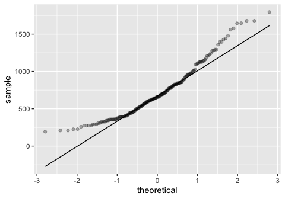

```r
## inspecionando distribuição

ggplot(tempo, aes(sample = tempo))+
  stat_qq(alpha=0.3)+
  stat_qq_line()
```

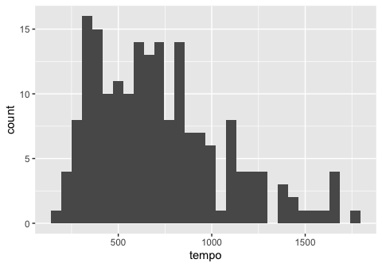

```r
ggplot(tempo, aes(x = tempo))+
  geom_histogram()
```

Essa distribuição não é normal: tem uma cauda assimétrica e longa à direita. Portanto, vamos normalizar esses valores. Criaremos uma nova coluna no *dataframe* tempo, chamada `tempo.log`. Essa nova coluna leverá os valores logarítmicos daqueles valores da coluna `tempo`.

Rode o código abaixo e você verá, no painel *Environment*, que o *dataframe* tem agora duas colunas. Você pode até inspecioná-lo para conferir.

```r
## criar coluna com valor log(tempo)

tempo$log.tempo = log(tempo$tempo)

## inspecionando a nova coluna

str(tempo)
```

```
#> 'data.frame':    192 obs. of  2 variables:
#>  $ tempo    : num  590 610 842 859 474 ...
#>  $ log.tempo: num  6.38 6.41 6.74 6.76 6.16 ...
```

Você pode ver agora que a distribuição desses valores é normal, e portanto deveria seguir sua análise considerando esses dados transformados como sua variável resposta.

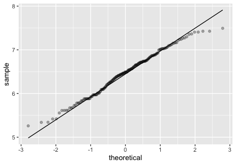

```r
## inspecionando nova distribuição

ggplot(tempo, aes(sample = log.tempo))+
  stat_qq(alpha=0.3)+
  stat_qq_line()
```

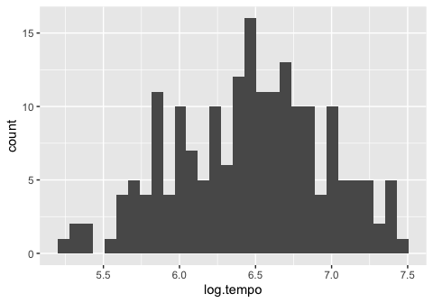

```r
ggplot(tempo, aes(x = log.tempo))+
  geom_histogram()
```

Agora que os dados estão normalizados, poderíamos seguir com as análises normalmente, usando como variável esse novo valor transformado, e não o valor bruto.

Algumas perguntas que você pode ter sobre transformação de valores são as seguintes:

- Essa é a única maneira de lidar com dados que violam a hipótese de normalidade?

Não. Uma outra maneira é buscar outros modelos estatísticos que não assumam normalidade dos resíduos. Para lidar com dados com medidas repetidas, há poucas opções desse tipo e vai depender do tipo de distribuição que você tem. Os dados que temos acima se assemelham a uma distribuição gama. Uma possibilidade seria ajustar um **modelo linear generalizado** (mais sobre isso na Seção 5) que assuma uma família de distribuições do tipo gama. Há autores que argumentam que essa é a melhor maneira de tratar dados que violam a normalidade, e que devemos preferir essa solução a uma transformação logarítmica (Lo e Andrews 2015). No entanto, em algumas áreas de estudo (como na psicologia e psicolinguística) é comum que os pesquisadores prefiram transformar seus dados.

- O que fazer quando, mesmo com a transformação, os dados continuam violando a normalidade?

Há duas respostas possíveis. A primeira é fazer a análise da mesma maneira e ver se os resíduos não tendem à normalidade. Lembre-se: a normalidade é uma hipótese sobre os resíduos do seu modelo.

Outra possibilidade seria procurar um modelo linear generalizado que não assuma a hipótese da normalidade, como discutido na questão anterior.

Qualquer que seja sua decisão, lembre-se de justificá-la com base na literatura da área. Às vezes nós não fazemos a melhor análise para os dados, mas sim a *melhor análise disponível*, e isso é muito diferente… A estatística também é uma área de estudos dinâmica, e há problemas de estatística aplicada para os quais ainda não temos respostas. Nesse caso, sacrificamos um pouco a precisão dos nossos modelos (e temos que decidir o que sacrificar) para fazer as análises que são possíveis naquele momento.

## 3.6 Resumindo o modelo linear misto

- Um modelo linear misto recebe esse nome porque conta com efeitos fixos e aleatórios;
- Iniciamos nossa análise construindo um modelo com o maior número possível de parâmetros de efeitos aleatórios, o que inclui interceptos e slopes aleatórios;
- Vamos diminuindo esses parâmatros se houver problemas de convergência;
- Ao chegarmos em um modelo máximo ajustado, prosseguimos a análise por comparação de modelos aninhados para determinar qual é o melhor e mais parcimonioso modelo ajustado aos dados;
- Precisamos conferir se nossos dados cumprem os requisitos para a construção de um modelo linear misto, o que inclui os requisitos vistos na última aula e a inclusão de medidas repetidas na estrutura de dados.

Se quiser saber mais sobre modelos lineares, consulte Baayen et al. (2008). Para um outro tutorial, veja Winter (2013). Para uma explicação sobre o porquê o uso de modelos lineares mistos é melhor do que uma ANOVA, veja Godoy e Nunes (em preparação).

## 3.7 Prática

O conjunto de dados *prediction.xlsx* contém os tempos de leitura de palavras críticas lidas durante um experimento de leitura auto-cadenciada que controlou 2 variáveis: tipo de contexto e tipo de palavra.

Os contextos eram de dois tipos: um **contexto preditivo**, que construía uma história em que uma palavra era esperada (“pedido”, no exemplo (1) abaixo), e um **contexto não-preditivo**, que não fazia com que qualquer palavra fosse particularmente esperada (caso do exemplo em (2)).

As palavras também eram de dois tipos: **palavra esperada** (“pedido”) ou **palavra inesperada** (“mensagem”) a partir do contexto preditivo.

1. **Contexto preditivo e palavra esperada:** A garçonete anotou o pedido.
2. **Contexto preditivo e palavra inesperada:** A garçonete anotou a mensagem.
3. **Contexto não-preditivo e palavra esperada:** Joana anotou o pedido.
4. **Contexto não-preditivo e palavra inesperada:** Joana anotou a mensagem.

A hipótese do estudo era de que as palavras esperadas seriam lidas mais rapidamente que as inesperadas apenas no contexto preditivo. Para isso, coletou-se o tempo de leitura de cada palavra crítica de sentenças semelhantes às apresentadas acima.

O conjunto de dados tem 6 colunas:

- `cod`, com identificação das 40 palavras alvo utilizadas como itens experimentais;
- `participante`, com identificação dos participantes da pesquisa;
- `rt`, com o tempo de leitura da palavra crítica;
- `contexto`, com indicação de contexto preditivo (`preditivo`) ou não-preditivo (`npreditivo`);
- `palavra`, com indicação se a palavra era esperada (`esp`) ou inesperada (`inesp`);
- `resposta`, indicando se o participante acertou a pergunta mostrada ao fim do item experimental, o que garante que ele estaria prestanto atenção (acertou = `sim`, errou = `nao`).

**Tarefa**

Para saber se a hipótese se confirmou,

- importe o conjunto de dados;
- inspecione a distribuição dos tempos de resposta para a palavra crítica e elimine outliers e observações com tempo de resposta maior que 2000ms (cf. Fraundorf e Jaeger 2016);
- transforme os dados se achar necessário;
- construa um modelo linear misto para analisar se tipo de contexto, tipo de palavra e a interação entre esses fatores conseguem explicar a distribuição de dados;
- faça análise por modelos aninhados se necessário.

Não se esqueça de ir anotando o seu código para mostrar o que você está fazendo e justificar suas decisões. Ao final, escreva os resultados como se fosse um artigo.

Para saber mais sobre esse estudo, veja Godoy et al. (2017).

## REFERÊNCIAS

Barr, D. J., Levy, R., Scheepers, C., and Tily, H. J. (2013). Random effects structure for confirmatory hypothesis testing: Keep it maximal. J. Mem. Lang. 68, 255–278. doi: 10.1016/j.jml.2012.11.001

Baayen, R. H., Davidson, D. J., & Bates, D. M. (2008). Mixed-effects modeling with crossed random effects for subjects and items. Journal of memory and language, 59(4), 390-412.

Clark, H. H. (1973). The language-as-fixed-effect fallacy: A critique of language statistics in psychological research. Journal of Verbal Learning and Verbal Behavior, 12, 335–359.

Enochson K, Culbertson J (2015) Collecting Psycholinguistic Response Time Data Using Amazon Mechanical Turk. PLoS ONE 10(3): e0116946. doi:10.1371/journal.pone.0116946

Fraundorf, S. H., & Jaeger, T. F. (2016). Readers generalize adaptation to newly-encountered dialectal structures to other unfamiliar structures. Journal of Memory and Language, 91, 28–58. https://doi.org/10.1016/j.jml.2016.05.006

Godoy, M.C., Vieira, C. B., Andrade, G. L., Souza-Filho, N., Nunes, M. A. (2017) O papel do conhecimento de eventos no processamento de sentenças isoladas. Revista Letrônica, v. 10, n. 2, p. 538-554.

Godoy, M. C., Nunes, M. A. (em preparação). Uma comparação entre ANOVA e modelos lineares mistos para análise de dados de tempo de reação.

Lo, S,; Andrews S. (2015) To transform or not to transform: using generalized linear mixed models to analyse reaction time data. Front. Psychol. 6:1171. doi: 10.3389/fpsyg.2015.01171

Schmalz, X., Robidoux, S., Castles, A., Coltheart, M., Marinus, E. (preprint): German and English bodies: No evidence for cross-linguistic differences in preferred grain size.

Winter, B. (2013). Linear models and linear mixed effects models in R with linguistic applications.  
arXiv:1308.5499. [http://arxiv.org/pdf/1308.5499.pdf]

[^1]: REML é a sigla, em inglês, para *REstricted Maximum Likelihood*. É uma técnica utilizada no ajuste de modelos lineares mistos para a estimação de parâmetros perturbadores. Os parâmetros perturbadores não são o objetivo final da análise, mas devem ser levados em conta na estimação dos parâmetros de interesse, como os coeficientes dos modelos lineares mistos. Exemplos de parâmetros perturbadores no contexto deste trabalho são as variabilidades por participante e por item dos experimentos de prime considerados.